# Space-time coregionalization model

Day 2, Afternoon

Instructor: Sara Martino

Start by loading useful libraries:

```r
library(ggplot2)
library(INLA)
library(inlabru)
library(viridis)
library(tidyverse)
library(patchwork)
```

In this practical we are going to implement a space-time coregionalization model. This is the same example in Chapter 8.1 of (Krainski 2019) but here we implement it using `inlabru`.

# 1 The model

We assume that we observe 3 variables $y_1(s,t)$, $y_2(s,t)$ and $y_3(s,t)$ over the same space domain $\s\in\mathcal{S}$ and over $t = 1,\dots,k$ time points.

The model is as following:

$$\begin{aligned}
y_1(s,t)&=\alpha_1+z_1(s,t) + e_1(s,t)\\
y_2(s,t)&=\alpha_2+\lambda_1\ z_1(s,t) + z_2(s,t)+ e_2(s,t)\\
y_3(s,t) &= \alpha_3+\lambda_2\ z_1(s,t)+\lambda_3\ z_2(s,t) + z_3(s,t) + e_3(s,t)
\end{aligned}$$

Where $\alpha_i$ are intercepts, $e_i(s,t)$ are uncorrelated noise with variances $\sigma^2_i$ and $\lambda_i$ are scaling factors.

Moreover, $z_i(s,t)$ are space-time Gaussian processes which change over time with first order autoregressive dynamics and spatially correlated innovations:
$$z_i(s,t) = \rho_i\ z_i(s,t-1) + \xi_i(s,t);\$$
with $t = 2,\dots,k$, $|\rho|<1$ and $z_i(s,1)\sim\mathcal{N}(0,\sigma^2_i/(1-\rho_i))$. The field $\xi_i(s,t)$ has mean 0 and is assumed to be temporally independent and with the covariance function
$$\text{Cov}(\xi_i(s,t), \xi_i(s',t')) =
\begin{cases}
0 & \text{if } & t\neq t'\\
\text{Cov}(\xi_i(s,t), \xi_i(s',t))& \text{if } & t= t'\\
\end{cases}$$
where $\text{Cov}(\xi_i(s,t), \xi_i(s',t))$ is a Matern spatial covariance function.

# 2 Data simulation

We use simulated data. You can think of the different observations as different measurements taken from the same measuring station. For example PM10, CO2 and NO2.

We define a function ti simulate a Matern field at given points:

```r
rMatern <- function(n, coords, sigma=1, range,
                    kappa = sqrt(8*nu)/range,
                    variance = sigma^2,
                    nu=1) {
  m <- as.matrix(dist(coords))
  m <- exp((1-nu)*log(2) + nu*log(kappa*m)-
             lgamma(nu))*besselK(m*kappa, nu)
  diag(m) <- 1
  return(drop(crossprod(chol(variance*m),
                        matrix(rnorm(nrow(coords)*n), ncol=n))))
}
```

We then define the area of interest and the parameters of the model

```r
# define the area of interest
p = Polygon(cbind(c(0,1,1,0,0),c(0,0,1,1,0)))
ps = Polygons(list(p),1)
space = SpatialPolygons(list(ps))

## ----param---------------------------------------------------------------
alpha <- c(-5, 3, 10) # intercept on reparametrized model
z.sigma = c(0.5, 0.6, 0.7) # random field marginal std
range = c(0.4, 0.6, 0.8) # GRF scales: range parameters
beta <- c(0.7, 0.5, -0.5) # copy par.: reparam. coreg. par.
rho <- c(0.7, 0.8, 0.9) # temporal correlations
n <- 50 # number of spatial locations
k <- 4  # number of time points
e.sigma <- c(0.3, 0.2, 0.15) # The measurement error marginal std
```

The next step is to simulate the location $s$. This time we assume that each station observes all 3 variables:

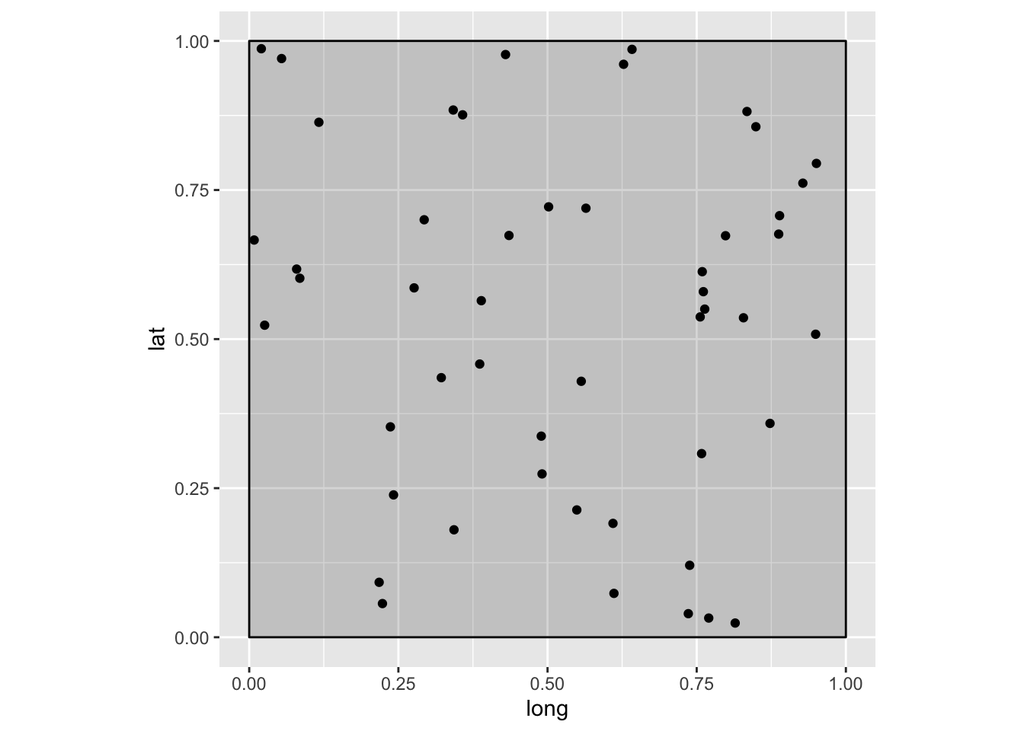

```r
loc <- cbind(runif(n), runif(n))
ggplot() + gg(space) +
  geom_point(data = data.frame(x = loc[,1],y = loc[,2]),
             aes(x,y)) + coord_equal( )
```

Now we simulate the space-time processes $z_i(s,t)$, $i =1,2,3$.

```r
## ----rfs, results = 'hide'-----------------------------------------------
x1 <- rMatern(k, loc, range = range[1], sigma = z.sigma[1])
x2 <- rMatern(k, loc, range = range[2], sigma = z.sigma[2])
x3 <- rMatern(k, loc, range = range[3], sigma = z.sigma[3])

z1 <- x1
z2 <- x2
z3 <- x3

for (j in 2:k) {
  z1[, j] <- rho[1] * z1[, j - 1] + sqrt(1 - rho[1]^2) * x1[, j]
  z2[, j] <- rho[2] * z2[, j - 1] + sqrt(1 - rho[2]^2) * x2[, j]
  z3[, j] <- rho[3] * z3[, j - 1] + sqrt(1 - rho[3]^2) * x3[, j]
}
```

Finally, we simulate the observations:

```r
## ----yyy-----------------------------------------------------------------
y1 <- alpha[1] + z1 + rnorm(n, 0, e.sigma[1])
y2 <- alpha[2] + beta[1] * z1 + z2 + rnorm(n, 0, e.sigma[2])
y3 <- alpha[3] + beta[2] * z1 + beta[3] * z2 + z3 +
  rnorm(n, 0, e.sigma[3])
```

```r
df1 = data.frame(x = loc[,1],
                 y = loc[,2],
                 z  = y1) %>%
  pivot_longer(-c(x,y)) %>%
  mutate(time = rep(1:k, n)) %>%
  dplyr::select(-name) %>%
  rename(z = value)
df2 = data.frame(x = loc[,1],
                 y = loc[,2],
                 z  = y2)%>%
  pivot_longer(-c(x,y)) %>%
  mutate(time = rep(1:k, n)) %>%
  dplyr::select(-name)%>%
  rename(z = value)
df3 = data.frame(x = loc[,1],
                 y = loc[,2],
                 z  = y3)%>%
  pivot_longer(-c(x,y)) %>%
  mutate(time = rep(1:k, n)) %>%
  dplyr::select(-name)%>%
  rename(z = value)
```

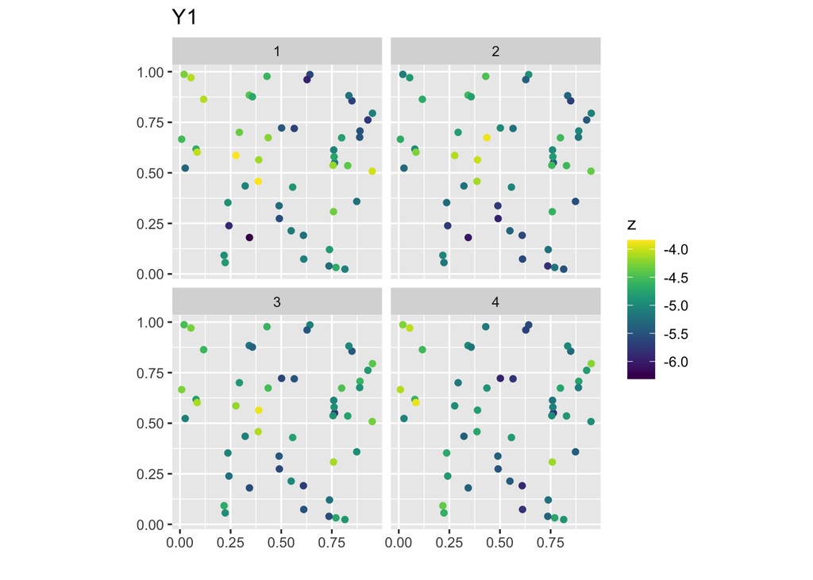

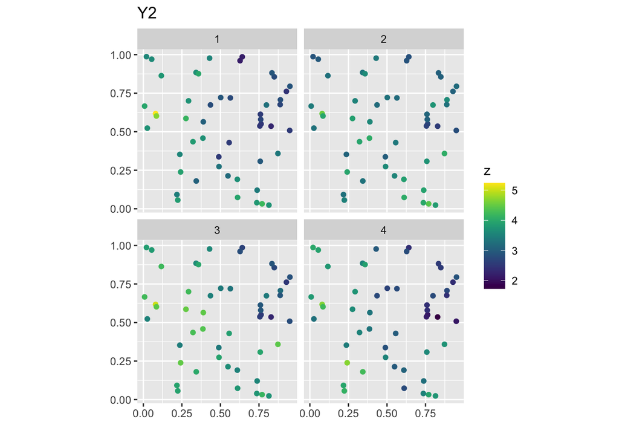

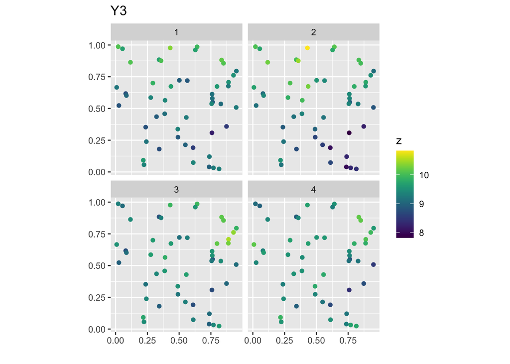

# 3 Model implementation

## 3.1 Build the mesh

Create the mesh

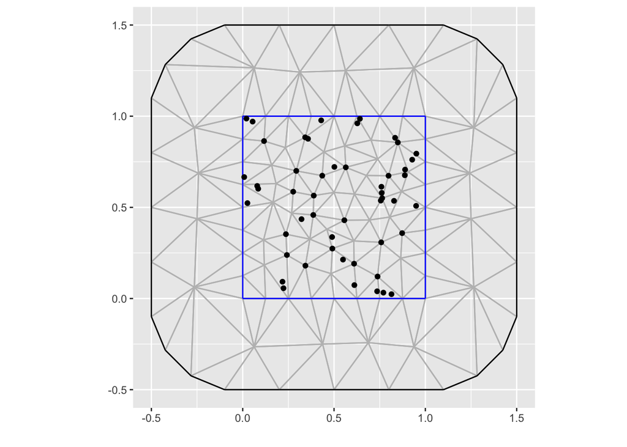

```r
## ----mesh----------------------------------------------------------------
mesh <- inla.mesh.2d(loc,
                     boundary = space,
                     max.edge = c(0.15,0.5),
                     offset = c(0.1,0.5),
  cutoff = 0.1)
ggplot() + gg(mesh)  + coord_equal()  + xlab("") + ylab("") +
  geom_point(data= data.frame(loc), aes(X1,X2))
```

## 3.2 Set up priors

In order to set up the model we need to choose priors for the range and sd of the Gaussian fields $z_i(s,t)$, for the parameters $\rho_i$ and for the scaling parameters $\lambda_i$, $i = 1,2,3$.

We set the parameters for the range and sd of the Gaussian fields in the SPDE object.

```r
spde <- inla.spde2.pcmatern(mesh = mesh,
  prior.range = c(0.05, 0.01), # P(range < 0.05) = 0.01
  prior.sigma = c(1, 0.01)) # P(sigma > 1) = 0.01
```

We can also plot the chosen priors:

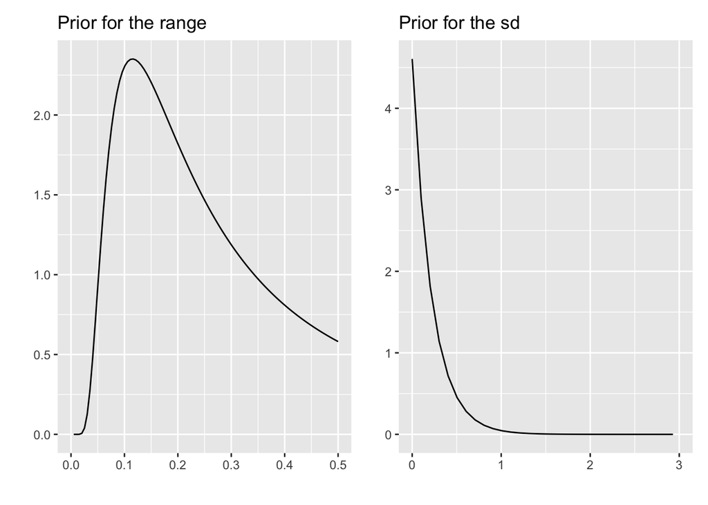

```r
dens_prior_range = function(rho_0, alpha_1)
{
  # compute the density of the PC prior for the
  # range rho of the Matern field
  # rho_0 and alpha_1 are defined such that
  # P(rho<rho_0) = alpha_1
  rho = seq(0, rho_0*10, length.out =100)
  alpha1_tilde = -log(alpha_1) * rho_0
  dens_rho =  alpha1_tilde / rho^2 * exp(-alpha1_tilde / rho)
  return(data.frame(x = rho, y = dens_rho))
}

dens_prior_sd = function(sigma_0, alpha_2)
{
  # compute the density of the PC prior for the
  # sd sigma of the Matern field
  # sigma_0 and alpha_2 are defined such that
  # P(sigma>sigma_0) = alpha_2
  sigma = seq(0, sigma_0*10, length.out =100)
  alpha2_tilde = -log(alpha_2)/sigma_0
  dens_sigma = alpha2_tilde* exp(-alpha2_tilde * sigma)
  return(data.frame(x = sigma, y = dens_sigma))
}

p1 = ggplot() + geom_line(data =  dens_prior_range(0.05, 0.01),
                     aes(x,y)) + xlab("")+ ylab("") +
  ggtitle("Prior for the range")
p2 = ggplot() + geom_line(data =  dens_prior_sd(1, 0.01),
                     aes(x,y)) + xlab("")+ ylab("") +
  ggtitle("Prior for the sd") + xlim(0,3)
p1+p2
```

For the parameters $\rho_i$ we use the PC prior called `pccor1` which assumes $rho = 1$ (that is a RW1 model) as the base model. See `inla.doc("pccor1")` for more information.

Below we set up the prior and plot it.

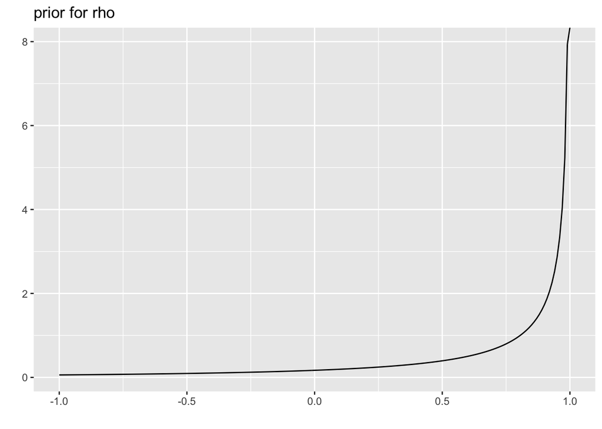

```r
rho1p <- list(theta = list(prior = 'pccor1', param = c(0, 0.9)))

data.frame(x = seq(-1,1,0.01),
           y = inla.pc.dcor1(seq(-1,1,0.01), u = 0, alpha = 0.9)) %>%
  ggplot() + geom_line(aes(x,y)) +
  xlab("") + ylab("") + ggtitle("prior for rho")
```

Last we need a prior for $\lambda_i$. Here we choose a Gaussian prior with mean 0 and precision 10

```r
hc1 <- list(theta = list(prior = 'normal', param = c(0, 10)))
```

## 3.4 Run the model

This model has 15 hyperparameters. To make the optimization process fast, the parameter values used in the simulation will be used as the initial values:

```r
theta.ini <- c(log(1 / e.sigma^2),
  c(log(range), log(z.sigma),
  qlogis(rho))[c(1, 4, 7, 2, 5, 8, 3, 6, 9)], beta)

# We jitter the starting values to avoid artificially
# recovering the true values
theta.ini = theta.ini + rnorm(length(theta.ini), 0, 0.1)
```

And finally we need to run the `bru()` function.

```r
res = bru(???,
          ???,
           options = list(verbose = F,
                         bru_max_iter = 1,
                         bru_verbose = 1,
                         control.mode = list(theta = theta.ini,
                                             restart = TRUE),
                         control.inla = list(int.strategy = 'eb'),
                         inla.mode  = "experimental"))
```

# 4 Results

## 4.1 Estimated parameters

Let’s have a look at the estimated parameters and compare them with the true ones.

Summary of the posterior distributions of the parameters in the model.

| Parameter | True | Mean | St. Dev. | 2.5% quant. | 97.5% quant. |
| --- | --- | --- | --- | --- | --- |
| Intercept1 | -5.000 | -4.711 | 0.290 | -5.281 | -4.141 |
| Intercept2 | 3.000 | 3.368 | 0.467 | 2.451 | 4.283 |
| Intercept3 | 10.000 | 9.528 | 0.550 | 8.447 | 10.608 |
| e1 | 11.111 | 31.888 | 6.981 | 19.851 | 47.098 |
| e2 | 25.000 | 41.599 | 7.821 | 28.434 | 59.113 |
| e3 | 44.444 | 58.190 | 9.705 | 41.264 | 79.378 |
| GroupRho for z1 | 0.700 | 0.939 | 0.032 | 0.857 | 0.977 |
| GroupRho for z2 | 0.800 | 0.949 | 0.022 | 0.895 | 0.980 |
| GroupRho for z3 | 0.900 | 0.946 | 0.025 | 0.884 | 0.980 |
| Beta for z1_copy | 0.700 | 0.214 | 0.123 | -0.019 | 0.464 |
| Beta for z1_copy2 | 0.500 | 0.520 | 0.085 | 0.352 | 0.686 |
| Beta for z2_copy | -0.500 | -0.328 | 0.094 | -0.512 | -0.142 |
| Range for z1 | 0.400 | 0.298 | 0.062 | 0.195 | 0.438 |
| Range for z2 | 0.600 | 0.581 | 0.111 | 0.395 | 0.830 |
| Range for z3 | 0.800 | 0.810 | 0.192 | 0.497 | 1.247 |
| Stdev for z1 | 0.500 | 1.026 | 0.224 | 0.635 | 1.511 |
| Stdev for z2 | 0.600 | 1.110 | 0.226 | 0.745 | 1.627 |
| Stdev for z3 | 0.700 | 0.931 | 0.209 | 0.582 | 1.402 |

## 4.2 Predictions at observation points

**Exercise 3:** Use the function `predict()` to compare the estimated linear predictors $\eta_i(s,t)$ with the observed values $y_i(s,t)$

```r
pred1 = predict(res, ??, ??)
pred2 = predict(res, ??, ??)
pred3 = predict(res, ??, ??)
```

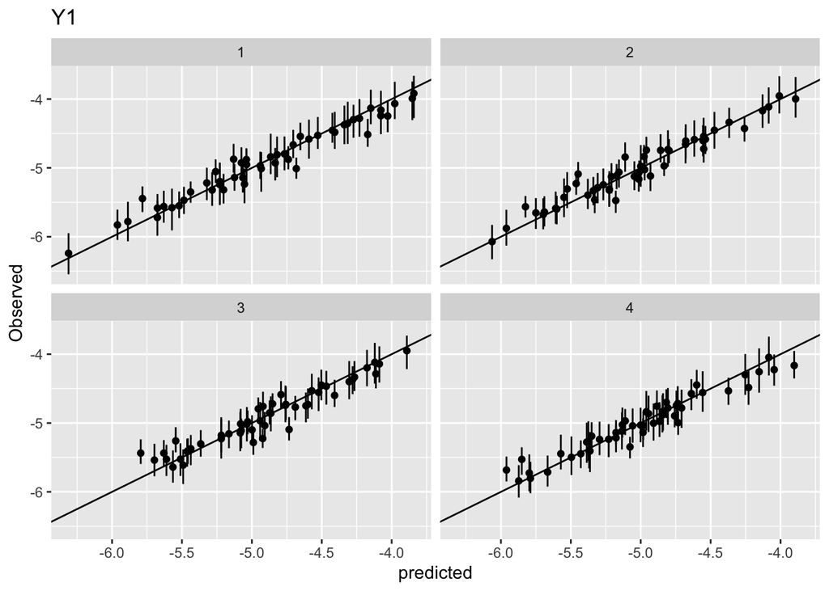

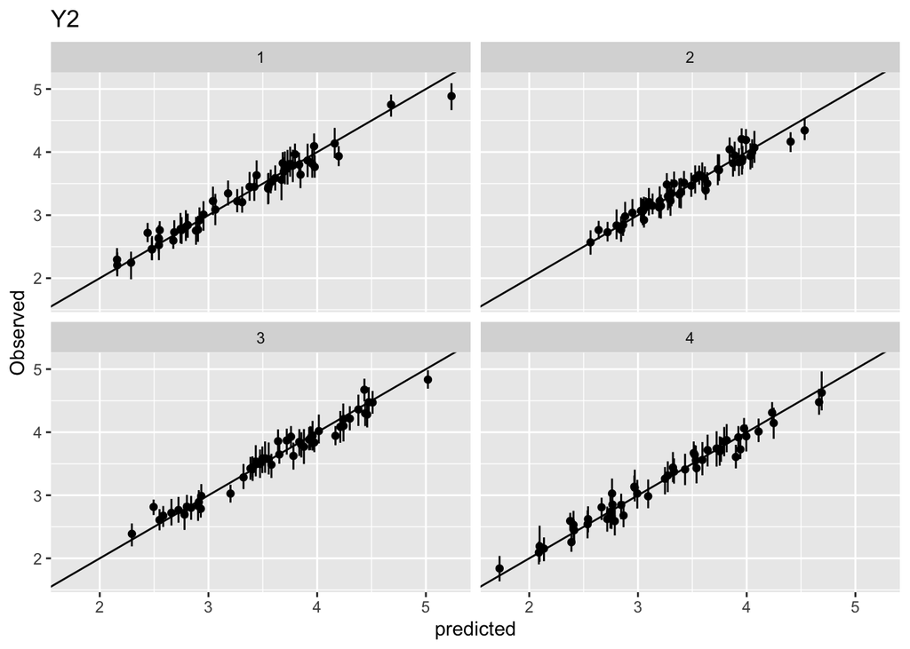

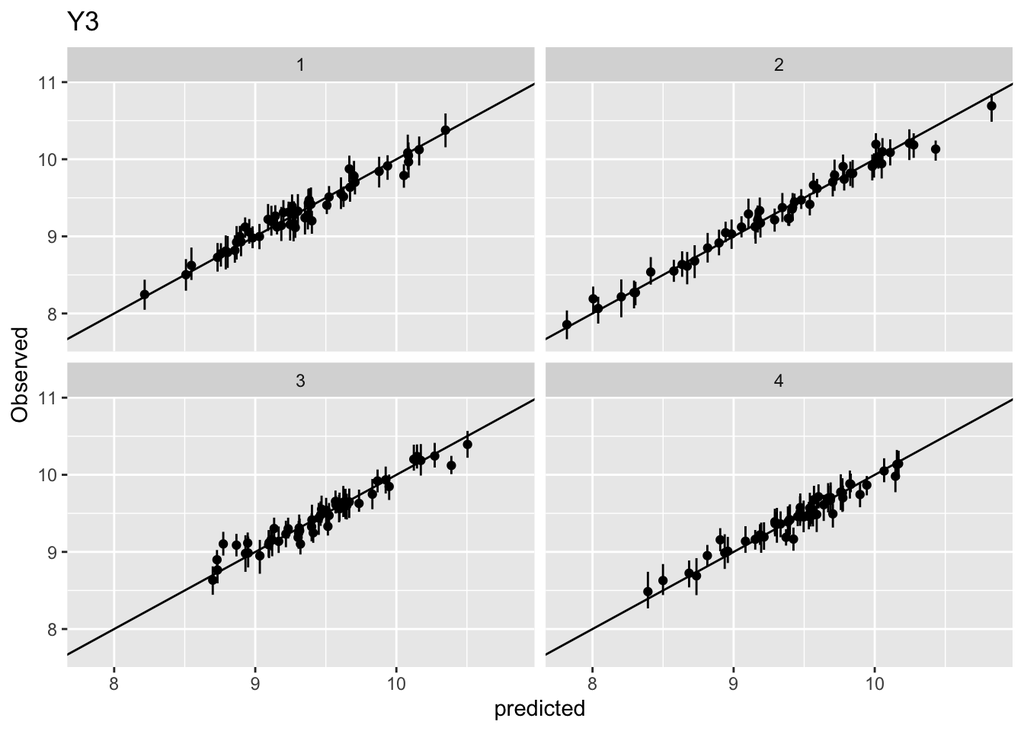

## 4.3 Estimation of the latent fields at the observation points

We can compare the estimated values of the latent fields $z_i(s,t)$ at the observation points with the true values we have simulated. Here is the code for $z_1(s,t)$:

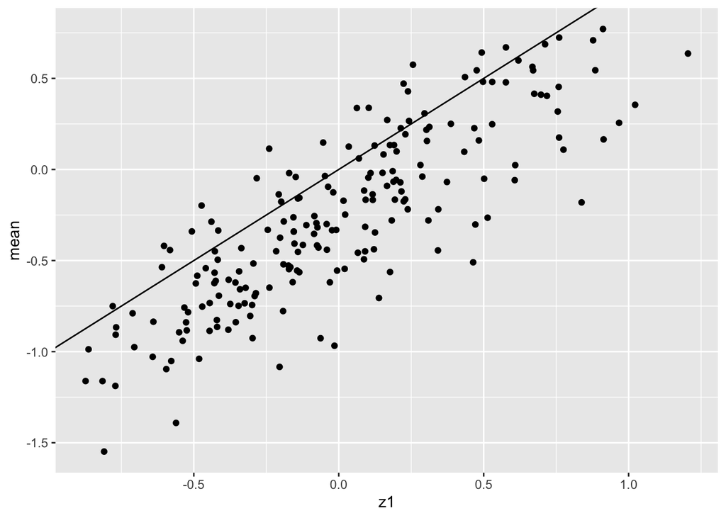

```r
z1_est = predict(res, df1, ~z1)
z1_est %>% mutate(z1 = as.vector(t(z1))) %>%
  ggplot()  + geom_point(aes(z1, mean)) +
  geom_abline(intercept = 0, slope = 1)
```

**Exercise 4:** Check that the estimates are reasonable also for the other two fields.

# 5 Prediction over the whole space

Finally we want to predict over the whole space of interest:

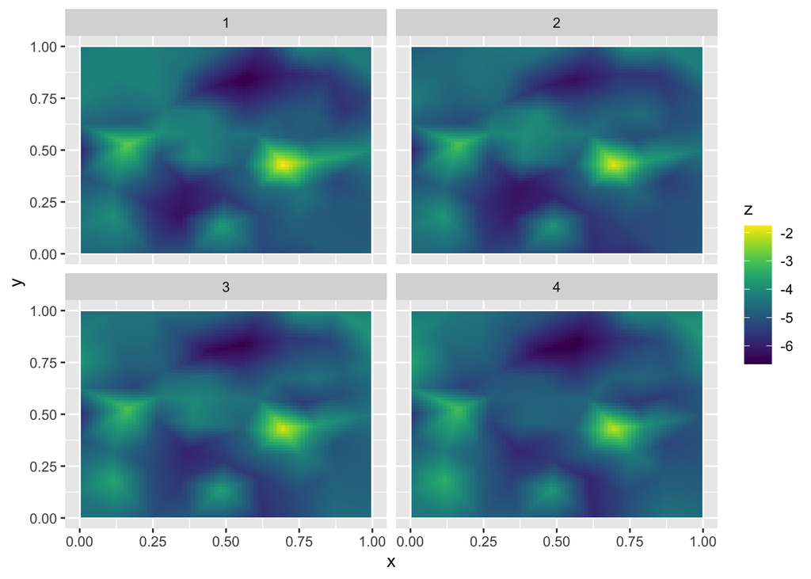

```r
pxl = pixels(mesh, mask = space)
ips2 <- ipoints(domain = c(1:4), name = "time")

pxl_time <- cbind(cprod(pxl,ips2))


aa = predict(res, pxl_time, ~ data.frame(eta1 = Intercept1 + z1,
                                          eta2 = Intercept2 + z1_copy + z2,
                                          eta3 = Intercept3 + z1_copy2 + z2_copy + z3 ))


# let's look at eta1
data.frame(x = rep(coordinates(pxl)[,1], each = k),
           y = rep(coordinates(pxl)[,2], each = k),
           time = pxl_time$time,
           z =  aa$eta1$mean) %>%
  ggplot() + geom_tile(aes(x,y,fill = z)) +
  facet_wrap(time~.) + scale_fill_viridis() +
  xlim(0,1) + ylim(0,1)
```

**Exercise 5:** Do you think the mesh is fine enought for this last goal?

# 6 Solutions

## 6.3 Exercise 3

```r
pred1 = predict(res, df1, ~Intercept1 + z1)
pred2 = predict(res, df2, ~Intercept2 + z1_copy + z2)
pred3 = predict(res, df3, ~Intercept3 + z1_copy2 + z2_copy + z3 )
```

Krainski, E. T et al. 2019. *Advanced Spatial Modeling with Stochastic Partial Differential Equations Using r and INLA.* CRC Press. Boca Raton, FL: Chapman & Hall.